# Wrangling Spotify

Burhanudin Badiuzaman

2024-08-27

# Step 1: Import packages

```r
#install.packages("outliers")
#install.packages("MVN")
#install.packages("here")
library(readr)
library(dplyr)
library(magrittr)
library(outliers)
library(MVN)
library(here)
library(tidyr)
```

```r
library(ggplot2)
library(kableExtra)
library(stringr)
library(splitstackshape)
library(lubridate)
library(editrules)
library(forecast)
```

# Step 2: Import Data

Paket readr digunakan untuk mengimpor dan membaca data dari file csv yang berisi kumpulan data. Untuk unpopular_songs.csv dan z_genre_of_artists.csv, kami memuat data ke dalam bingkai data unpopular_songs dan genre.

Please confirmed that you in work directory:

```r
getwd()
```

```
## [1] "/Users/burhanudin/Study_burhanudin_6/R/Code-R/Data_Analyst_in_R"
```

```r
setwd("/Users/burhanudin/Study_burhanudin_6/R/Code-R/Data_Analyst_in_R")
```

```r
#Import the two csv files and save them in separate data frames
unpopular_songs <- read_csv("data/unpopular_songs.csv")
genre <- read_csv("data/z_genre_of_artists.csv")
```

```
## ──────────────────────────────────────────────────────── Delimiter: "," chr
## (3): artist_name, artist_id, genre dbl (1): ...1
```

# Step 3: Data Sets Overview

- Kita mulai dengan memeriksa 6 baris awal dari kedua kumpulan data. Dengan menggunakan fungsi head(), kita memeriksa 6 baris pertama dari setiap kumpulan data.

```r
#Show the first six rows of "unpopular_songs" dataframe
head(unpopular_songs)
```

```
## # A tibble: 6 × 17
##   danceability energy   key loudness  mode speechiness acousticness
##          <dbl>  <dbl> <dbl>    <dbl> <dbl>       <dbl>        <dbl>
## 1        0.722  0.476     5    -8.20     1      0.0896       0.67
## 2        0.955  0.281     0   -11.4      0      0.466        0.0048
## 3        0.753  0.355     8   -11.8      1      0.514        0.573
## 4        0.65   0.331     3   -10.8      0      0.383        0.865
## 5        0.69   0.36      4   -15.6      0      0.455        0.764
## 6        0.849  0.275     6   -15.7      0      0.694        0.414
## # ℹ 10 more variables: instrumentalness <dbl>, liveness <dbl>, valence <dbl>,
## #   tempo <dbl>, duration_ms <dbl>, explicit <lgl>, popularity <dbl>,
## #   track_name <chr>, track_artist <chr>, track_id <chr>
```

```r
#Show the first six rows of "genre" data frame
head(genre)
```

```
## # A tibble: 6 × 4
##    ...1 artist_name artist_id              genre
##   <dbl> <chr>       <chr>                  <chr>
## 1     0 El Javi     6qZksHG4gzbRx3FZplO4Ls []
## 2     1 Br80        3x0tOQYysaBspzDp0PGDoM []
## 3     2 JpThaRuler  1n5X8uMaNKFI4BAXFpD2AZ ['westcoast flow']
## 4     3 Jimmy D     7g0eqYROzcQjp6Jflh7dPT []
## 5     4 Kafime      2PkEwFBI1VcQL5VYtFMd9h []
## 6     5 Yvng 7      2ZWVQzEjNfIydXDKtQalWN []
```

```r
#Check the number of observations in "unpopular_songs"
unpopular_songs %>% count()
```

```
## # A tibble: 1 × 1
##       n
##   <int>
## 1  4073
```

```r
#Check the number of observations in "genre"
genre %>% count()
```

```
## # A tibble: 1 × 1
##       n
##   <int>
## 1   701
```

- Hasil `count()` mengungkapkan bahwa variabel “lagu tidak populer” dan “genre” masing-masing memiliki 4073 dan 701 observasi.

# Step 4: Remove Duplicates

- Untuk mengidentifikasi dan menghapus semua observasi yang terduplikasi, kami menggunakan fungsi `unique()` atau `distinct()` untuk memeriksa jumlah observasi yang berbeda. Setelah menghilangkan observasi yang terduplikasi, jumlah observasi yang unik dihitung dengan fungsi `count()`

```r
#Check the distinct number of observations in "unpopular_songs"
unpopular_songs %>% unique() %>% count()
```

```
## # A tibble: 1 × 1
##       n
##   <int>
## 1  4073
```

```r
#Check the distinct number of observations in "genre"
genre %>% distinct() %>% count()
```

```
## # A tibble: 1 × 1
##       n
##   <int>
## 1   701
```

- Hasil count() mengungkapkan bahwa variabel “lagu tidak populer” dan “genre” masing-masing memiliki 4073 dan 701 observasi berbeda.
- Karena memilihi hasil angka syang sama dari hasil pengamatan `distinc()` dan `count()` sehingga daopat di simpulkan `tidak ada duplikasi data`

# Step 5: Merge Data Sets

Fungsi left_join dari paket dplyr digunakan untuk menggabungkan dua set data (unpopular_songs dan genre) berdasarkan variabel umum “track_artist” pada set data pertama dan “artist_name” pada set data kedua. Left join memastikan bahwa semua baris dari set data unpopular_songs dipertahankan, dan baris yang cocok dari set data new_genre ditambahkan, sehingga menghasilkan set data gabungan tempat informasi dari kedua set data digabungkan berdasarkan variabel yang ditentukan. Kerangka data baru bernama “songs” dibuat.

```r
songs <- unpopular_songs %>% left_join(genre, by=c("track_artist"="artist_name"))
# Head data songs
head(songs)
```

```
## # A tibble: 6 × 20
##   danceability energy   key loudness  mode speechiness acousticness
##          <dbl>  <dbl> <dbl>    <dbl> <dbl>       <dbl>        <dbl>
## 1        0.722  0.476     5    -8.20     1      0.0896       0.67
## 2        0.722  0.476     5    -8.20     1      0.0896       0.67
## 3        0.955  0.281     0   -11.4      0      0.466        0.0048
## 4        0.753  0.355     8   -11.8      1      0.514        0.573
## 5        0.65   0.331     3   -10.8      0      0.383        0.865
## 6        0.69   0.36      4   -15.6      0      0.455        0.764
## # ℹ 13 more variables: instrumentalness <dbl>, liveness <dbl>, valence <dbl>,
## #   tempo <dbl>, duration_ms <dbl>, explicit <lgl>, popularity <dbl>,
## #   track_name <chr>, track_artist <chr>, track_id <chr>, ...1 <dbl>,
## #   artist_id <chr>, genre <chr>
```

# Step 6: Check Data Structure

- Selanjutnya, kita akan memeriksa struktur data dan tipe variabel. Pertama, kita periksa dimensi kerangka data menggunakan fungsi dim().

```r
#Checking dimenions of songs
dim(songs)
```

```
## [1] 4630   20
```

- Kemudian kami memeriksa tipe variabel pada kumpulan data gabungan “lagu” menggunakan fungsi `str()`.

```r
# Checking the structure of the data
str(songs)
```

```
## spc_tbl_ [4,630 × 20] (S3: spec_tbl_df/tbl_df/tbl/data.frame)
##  $ danceability    : num [1:4630] 0.722 0.722 0.955 0.753 0.65 0.69 0.849 0.846 0.725 0.724 ...
##  $ energy          : num [1:4630] 0.476 0.476 0.281 0.355 0.331 0.36 0.275 0.269 0.235 0.315 ...
##  $ key             : num [1:4630] 5 5 0 8 3 4 6 9 6 10 ...
##  $ loudness        : num [1:4630] -8.2 -8.2 -11.4 -11.8 -10.8 ...
##  $ mode            : num [1:4630] 1 1 0 1 0 0 0 0 0 0 ...
##  $ speechiness     : num [1:4630] 0.0896 0.0896 0.466 0.514 0.383 0.455 0.694 0.46 0.507 0.861 ...
##  $ acousticness    : num [1:4630] 0.67 0.67 0.0048 0.573 0.865 0.764 0.414 0.756 0.748 0.445 ...
##  $ instrumentalness: num [1:4630] 0 0 0.0595 0 0 0 0 0 0 0 ...
##  $ liveness        : num [1:4630] 0.0926 0.0926 0.122 0.0735 0.105 0.181 0.0776 0.0914 0.116 0.0863 ...
##  $ valence         : num [1:4630] 0.927 0.927 0.0934 0.6 0.581 0.105 0.376 0.318 0.549 0.531 ...
##  $ tempo           : num [1:4630] 152 152 128 92 99.5 ...
##  $ duration_ms     : num [1:4630] 220549 220549 149543 130019 116193 ...
##  $ explicit        : logi [1:4630] FALSE FALSE TRUE TRUE TRUE TRUE ...
##  $ popularity      : num [1:4630] 8 8 0 0 0 0 0 0 0 0 ...
##  $ track_name      : chr [1:4630] "Este Corazón" "Este Corazón" "thinking and doing" "Puzzlement" ...
##  $ track_artist    : chr [1:4630] "El Javi" "El Javi" "Br80" "JpThaRuler" ...
##  $ track_id        : chr [1:4630] "0Z4UqiPI5c4dMJ5iPyO61d" "0Z4UqiPI5c4dMJ5iPyO61d" "568FGhLEnSZhl82t0YmQ96" "4Lex8QZVkptfw2PZtjoXlp" ...
##  $ ...1            : num [1:4630] 0 555 1 2 2 2 2 2 2 2 ...
##  $ artist_id       : chr [1:4630] "6qZksHG4gzbRx3FZplO4Ls" "6qZksHG4gzbRx3FZplO4Ls" "3x0tOQYysaBspzDp0PGDoM" "1n5X8uMaNKFI4BAXFpD2AZ" ...
##  $ genre           : chr [1:4630] "[]" "[]" "[]" "['westcoast flow']" ...
##  - attr(*, "spec")=
##   .. cols(
##   ..   danceability = col_double(),
##   ..   energy = col_double(),
##   ..   key = col_double(),
##   ..   loudness = col_double(),
##   ..   mode = col_double(),
##   ..   speechiness = col_double(),
##   ..   acousticness = col_double(),
##   ..   instrumentalness = col_double(),
##   ..   liveness = col_double(),
##   ..   valence = col_double(),
##   ..   tempo = col_double(),
##   ..   duration_ms = col_double(),
##   ..   explicit = col_logical(),
##   ..   popularity = col_double(),
##   ..   track_name = col_character(),
##   ..   track_artist = col_character(),
##   ..   track_id = col_character()
##   .. )
##  - attr(*, "problems")=<externalptr>
```

- Sebagian besar variabel bersifat numerik (misalnya valensi, tempo, durasi ms). Variabel-variabel tersebut mewakili elemen musik dari lagu tersebut. Ada beberapa unit untuk beberapa variabel, termasuk dB, BPM, dan milidetik. “Eksplisit” adalah variabel unik yang memiliki struktur berbasis logika karena variabel tersebut diambil dari data asli sebagai BENAR atau SALAH. Parameter yang tersisa (nama trek, artis trek, id trek, id artis, dan genre) mengambil tipe data karakter.
- Selanjutnya, kita akan menerapkan konversi tipe data. Popularitas dalam kumpulan data ini menandakan peringkat lagu, dengan 0 menunjukkan peringkat terendah dan 18 menunjukkan peringkat tertinggi. Oleh karena itu, kita mengubah tipe data “popularitas” dari numerik menjadi faktor terurut menggunakan fungsi factor().

```r
# Converting the data type to factor
songs$popularity <- factor(songs$popularity,
                           levels=c("0", "1", "2", "3", "4", "5", "6", "7",
                                       "8", "9", "10", "11", "12", "13", "14",
                                       "15", "16", "17", "18"),
                           ordered = TRUE)
```

- Kemudian kami memverifikasi apakah transformasi berhasil atau tidak menggunakan fungsi `class()`. Transformasi yang berhasil ditunjukkan oleh fungsi yang mengembalikan “ordered” dan “factor” sebagai tipe data.

```r
class(songs$popularity)
```

```
## [1] "ordered" "factor"
```

- Selanjutnya, kita ubah “modus” dari variabel numerik menjadi faktor. Pengamatan pada kolom modus direpresentasikan dengan angka 0 dan 1. Kita beri label 0 sebagai “mayor” dan 1 sebagai “minor” untuk menghindari kebingungan dan agar lebih mudah dipahami.

```r
songs$mode <- factor(songs$mode,
                     levels = c("0","1"),
                     labels = c("Major","Minor"))
```

```r
# Periksa data
head(songs)
```

```
## # A tibble: 6 × 20
##   danceability energy   key loudness mode  speechiness acousticness
##          <dbl>  <dbl> <dbl>    <dbl> <fct>       <dbl>        <dbl>
## 1        0.722  0.476     5    -8.20 Minor      0.0896       0.67
## 2        0.722  0.476     5    -8.20 Minor      0.0896       0.67
## 3        0.955  0.281     0   -11.4  Major      0.466        0.0048
## 4        0.753  0.355     8   -11.8  Minor      0.514        0.573
## 5        0.65   0.331     3   -10.8  Major      0.383        0.865
## 6        0.69   0.36      4   -15.6  Major      0.455        0.764
## # ℹ 13 more variables: instrumentalness <dbl>, liveness <dbl>, valence <dbl>,
## #   tempo <dbl>, duration_ms <dbl>, explicit <lgl>, popularity <ord>,
## #   track_name <chr>, track_artist <chr>, track_id <chr>, ...1 <dbl>,
## #   artist_id <chr>, genre <chr>
```

# Step 7.1: Tidy & Manipulate I

- Menurut Wickham dan Grolemund (2016), ada tiga aturan yang saling terkait yang membuat kumpulan data rapi.
1. Setiap variabel harus memiliki kolomnya sendiri.
2. Setiap observasi harus memiliki barisnya sendiri.
3. Setiap nilai harus memiliki selnya sendiri.
- Untuk kumpulan data “lagu”, ia mematuhi aturan pertama dan kedua karena setiap variabel membentuk kolomnya sendiri dan setiap trek membentuk barisnya sendiri. Namun, urutan kolom tidak terlalu lengkap karena kolom nama trek diposisikan setelah sebagian besar variabel, seperti `duration_ms`, `popularity`, dll. Ini akan dirapikan pada tahap selanjutnya.
- Meskipun demikian, ia tidak mematuhi aturan ketiga karena setiap nilai tidak memiliki selnya sendiri saat kita memeriksa nilai di bawah kolom `genre`.

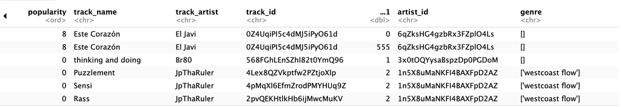

+ Untuk memastikan bentuk konsisten yang sesuai dengan semantik kumpulan data dengan cara penyimpanannya, kita perlu membentuk ulang dan merapikan data menggunakan berbagai fungsi.

## Merapikan(Tidying) kolom “genre”

- Pengamatan harus dibersihkan dengan menghapus simbol atau tanda kurung tambahan, dan urutan nilai harus disusun ulang untuk memastikan bahwa setiap sel hanya memiliki satu nilai. Pertama, kita menggunakan fungsi `str_sub` untuk menghilangkan “[ ]” yang tidak diinginkan dari setiap nilai di kolom genre.

```r
songs$genre <- str_sub(songs$genre, start=2L, end=nchar(songs$genre)-1L)
```

```r
head(songs)
```

```
## # A tibble: 6 × 20
##   danceability energy   key loudness mode  speechiness acousticness
##          <dbl>  <dbl> <dbl>    <dbl> <fct>       <dbl>        <dbl>
## 1        0.722  0.476     5    -8.20 Minor      0.0896       0.67
## 2        0.722  0.476     5    -8.20 Minor      0.0896       0.67
## 3        0.955  0.281     0   -11.4  Major      0.466        0.0048
## 4        0.753  0.355     8   -11.8  Minor      0.514        0.573
## 5        0.65   0.331     3   -10.8  Major      0.383        0.865
## 6        0.69   0.36      4   -15.6  Major      0.455        0.764
## # ℹ 13 more variables: instrumentalness <dbl>, liveness <dbl>, valence <dbl>,
## #   tempo <dbl>, duration_ms <dbl>, explicit <lgl>, popularity <ord>,
## #   track_name <chr>, track_artist <chr>, track_id <chr>, ...1 <dbl>,
## #   artist_id <chr>, genre <chr>
```

- Setelah itu, setiap nilai dibagi ke dalam selnya sendiri dan diubah ke format panjang menggunakan fungsi `cSpilt`. Nilai diubah ke format panjang karena kita mengikuti Prinsip Data Rapi 2 yang menyatakan bahwa setiap pengamatan harus memiliki barisnya sendiri.

```r
songs_2 <- cSplit(songs, "genre", sep=",", direction="long")
head(songs_2)
```

```
##    danceability energy   key loudness   mode speechiness acousticness
##           <num>  <num> <num>    <num> <fctr>       <num>        <num>
## 1:        0.753  0.355     8  -11.799  Minor       0.514        0.573
## 2:        0.650  0.331     3  -10.818  Major       0.383        0.865
## 3:        0.690  0.360     4  -15.624  Major       0.455        0.764
## 4:        0.849  0.275     6  -15.728  Major       0.694        0.414
## 5:        0.846  0.269     9  -11.843  Major       0.460        0.756
## 6:        0.725  0.235     6  -16.269  Major       0.507        0.748
##    instrumentalness liveness valence   tempo duration_ms explicit popularity
##               <num>    <num>   <num>   <num>       <num>   <lgcl>      <ord>
## 1:                0   0.0735   0.600  91.978      130019     TRUE          0
## 2:                0   0.1050   0.581  99.513      116193     TRUE          0
## 3:                0   0.1810   0.105  89.893      111827     TRUE          0
## 4:                0   0.0776   0.376 102.053      128546     TRUE          0
## 5:                0   0.0914   0.318  91.991      139527     TRUE          0
```

[output cut: 17 more lines]

- Untuk menghilangkan ’ ’ yang tidak diinginkan dari nilai, fungsi `str_sub` diterapkan.

```r
songs_2$genre <- str_sub(songs_2$genre, start=2L, end=nchar(songs_2$genre)-1L)
```

```r
head(songs_2)
```

```
##    danceability energy   key loudness   mode speechiness acousticness
##           <num>  <num> <num>    <num> <fctr>       <num>        <num>
## 1:        0.753  0.355     8  -11.799  Minor       0.514        0.573
## 2:        0.650  0.331     3  -10.818  Major       0.383        0.865
## 3:        0.690  0.360     4  -15.624  Major       0.455        0.764
## 4:        0.849  0.275     6  -15.728  Major       0.694        0.414
## 5:        0.846  0.269     9  -11.843  Major       0.460        0.756
## 6:        0.725  0.235     6  -16.269  Major       0.507        0.748
##    instrumentalness liveness valence   tempo duration_ms explicit popularity
##               <num>    <num>   <num>   <num>       <num>   <lgcl>      <ord>
## 1:                0   0.0735   0.600  91.978      130019     TRUE          0
## 2:                0   0.1050   0.581  99.513      116193     TRUE          0
## 3:                0   0.1810   0.105  89.893      111827     TRUE          0
## 4:                0   0.0776   0.376 102.053      128546     TRUE          0
## 5:                0   0.0914   0.318  91.991      139527     TRUE          0
```

[output cut: 17 more lines]

- Karena kita bekerja dengan kerangka data yang besar, kita hanya ingin menilai variabel tertentu. Fungsi `select()` memungkinkan kita untuk memilih variabel. Karena fungsi `dplyr` tidak akan mengubah input, kita menggunakan operator penugasan untuk menyimpan hasil sebagai kumpulan data baru yang disebut `songs_selected`. Kita kemudian menerapkan fungsi `arrange()` untuk mengurutkan kumpulan data berdasarkan popularitas dan nama lagu dalam urutan menaik. Terakhir, kita menyaring lagu-lagu dengan popularitas sama dengan 0 dan mengompilasinya ke dalam kerangka data baru yang disebut `unpopular_genre` untuk mengidentifikasi lagu-lagu yang paling tidak populer dalam genre masing-masing. Beberapa lagu tidak dikategorikan, yang berisi nilai NA. Kita menggunakan `drop_na()` untuk membuang nilai null apa pun.

```r
#Select columns by name using the pipe operator and save it in a new data set
songs_selected <- songs_2 %>% select(popularity, track_name, track_artist, mode, duration_ms, genre)

#Order the data set according to two variables
songs_selected %<>% arrange(popularity, track_name)

# Select songs with 0 popularity, then group them by genre
unpopular_genre <- songs_selected %>% filter(popularity == "0") %>% group_by(genre) %>%
  summarise(number_of_most_unpopular_songs = n())

# Arrange them by descending order
unpopular_genre %>% arrange(desc(number_of_most_unpopular_songs)) %>% drop_na()
```

```
## # A tibble: 186 × 2
##    genre             number_of_most_unpopular_songs
##    <chr>                                      <int>
##  1 go-go                                         52
##  2 binaural                                      50
##  3 white noise                                   29
##  4 latin pop                                     28
##  5 mandolin                                      26
##  6 musica de fondo                               26
##  7 pianissimo                                    26
##  8 world meditation                              26
##  9 latin alternative                             24
## 10 tejano                                        23
## # ℹ 176 more rows
```

```r
head(songs_selected,10)
```

```
##     popularity              track_name       track_artist   mode duration_ms
##          <ord>                  <char>             <char> <fctr>       <num>
##  1:          0                      10         JpThaRuler  Major      139527
##  2:          0             18 and Life           Skid Row  Major      229960
##  3:          0                    1967       Adrian Belew  Minor      330667
##  4:          0                   4Play        Wavytheking  Minor       61320
##  5:          0     80Hz Low Pink Noise Pink Noise Therapy  Minor      203267
##  6:          0 A Cambio de Qué - Salsa        Huey Dunbar  Minor      262440
##  7:          0 A Holly Jolly Christmas       Steve Chavez  Minor      174013
##  8:          0           A Little Busy Bobby Timmons Trio  Minor      350133
##  9:          0         A Medio Meditar        Golpe Justo  Minor      114533
## 10:          0         A Pesar de Todo        Luigi Arias  Minor      275480
##                  genre
##                 <char>
##  1:     westcoast flow
##  2:               <NA>
##  3:               <NA>
##  4:   kentucky hip hop
##  5:        white noise
##  6:               <NA>
##  7:   new mexico music
##  8:               <NA>
##  9:  puerto rican rock
## 10: bachata dominicana
```

# Step 7.2: Tidy & Manipulate II

- Setelah merapikan data, kami ingin mengubah variabel baru dari variabel duration_ms yang ada untuk memudahkan pemahaman data waktu. Saat ini durasinya dalam milidetik, tetapi kami ingin mengubah satuannya menjadi detik dan menit. Di sini kami akan menggunakan fungsi seconds_to_period() dari paket lubridate untuk menangani data waktu.
- Karena kumpulan data asli menyediakan data waktu dalam milidetik, pertama-tama kita akan membagi duration_ms dengan 1000 sebelum menerapkan fungsi `seconds_to_period()`.

```r
#Use seconds_to_period function to transform duration_ms
songlength <- seconds_to_period(songs_selected$duration_ms/1000)

#Checking if the transformation is successful
head(songlength)
```

```
## [1] "2M 19.527S" "3M 49.96S"  "5M 30.667S" "1M 1.32S"   "3M 23.267S"
## [6] "4M 22.44S"
```

```r
#Check the class of songlength
class(songlength)
```

```
## [1] "Period"
## attr(,"package")
## [1] "lubridate"
```

- Kami menambahkan satu variabel baru menggunakan fungsi mutate() dari paket dplyr. Kemudian kami memeriksa apakah variabel baru telah berhasil ditambahkan ke kerangka data.

```r
#Create new variables "duration_min"

#Then drop the existing variable "duration_ms"
songs_selected %<>%
  mutate(songs_selected, duration_min = round(songlength)) %>%
  select (-duration_ms)

#Checking the class of songlength
glimpse(songs_selected)
```

```
## Rows: 3,557
## Columns: 6
## $ popularity   <ord> 0, 0, 0, 0, 0, 0, 0, 0, 0, 0, 0, 0, 0, 0, 0, 0, 0, 0, 0, …
## $ track_name   <chr> "10", "18 and Life", "1967", "4Play", "80Hz Low Pink Nois…
## $ track_artist <chr> "JpThaRuler", "Skid Row", "Adrian Belew", "Wavytheking", …
## $ mode         <fct> Major, Major, Minor, Minor, Minor, Minor, Minor, Minor, M…
## $ genre        <chr> "westcoast flow", NA, NA, "kentucky hip hop", "white nois…
## $ duration_min <Period> 2M 20S, 3M 50S, 5M 31S, 1M 1S, 3M 23S, 4M 22S, 2M 54S,…
```

# Step 7.3: Tidy & Manipulate III

## Scanning Nilai yang Hilang

- Saat kita membaca data dari dua file csv, setiap nilai yang hilang akan direpresentasikan sebagai NA untuk integer, untuk variabel karakter. Untuk mengidentifikasi nilai yang hilang dalam kerangka data, kita dapat menggunakan fungsi is.na() yang digabungkan dengan fungsi colSums() untuk menemukan total nilai yang hilang di setiap kolom dalam kerangka data kita.

```r
# Identitfiy total number NAs in each column
colSums(is.na(songs_selected))
```

```
##   popularity   track_name track_artist         mode        genre duration_min
##            0            0            0            0          515            0
```

- Kami menemukan bahwa kolom “genre” memiliki 515 nilai NA. Karena bukan numerik, kami tidak dapat mengode ulang nilai yang hilang menggunakan operasi subset dan penugasan normal. Cara terbaik adalah menggunakan fungsi replace_na() dari paket tidyr untuk mengganti nilai NA. Karena NA berarti lagu tersebut tidak dikategorikan, kami dapat mengganti NA dengan karakter “tidak dikategorikan” untuk pemahaman yang lebih baik.

```r
# Replace NA values in "genre"
songs_selected$genre <- replace_na(songs_selected$genre, "uncategorized")

# Check total number of NAs in each column again to confirm there is no missing value in the data frame
colSums(is.na(songs_selected))
```

```
##   popularity   track_name track_artist         mode        genre duration_min
##            0            0            0            0            0            0
```

## Scanning Nilai Khusus

- Setelah menangani nilai yang hilang, kita akan memeriksa apakah ada nilai khusus, yaitu -Inf, Inf, dan NaN. Kita dapat menggunakan fungsi is.finite, is.infinite, atau is.nan untuk mengidentifikasi nilai khusus dalam satu set data. Karena kita memeriksa seluruh kerangka data, kita perlu menggunakan fungsi keluarga apply. Kita menggunakan fungsi sapply di sini. Fungsi ini dapat diterapkan ke suatu daftar. Karena kerangka data memiliki karakteristik baik daftar maupun matriks, sapply dapat diterapkan ke kerangka data.
- Kita buat fungsi baru untuk memeriksa jumlah nilai tak terhingga atau NaN atau NA untuk kolom numerik, dan jumlah nilai NA untuk kolom lainnya. Kita tulis fungsi di dalam sapply() dan hitung total nilai yang hilang untuk setiap kolom.

```r
# Check every numerical column whether they have infinite or NaN or NA values using a function
sapply(songs_selected, function(x) {
  if(is.numeric(x)) {sum(is.infinite(x) | is.nan(x) | is.na(x))}
  else {sum(is.na(x))}
    })
```

```
##   popularity   track_name track_artist         mode        genre duration_min
##            0            0            0            0            0            0
```

## Memindai Kesalahan yang Jelas

- Selanjutnya, kita akan memeriksa apakah ada ketidakkonsistenan yang jelas yang mungkin tidak sesuai dengan situasi di dunia nyata. Misalnya, durasi lagu tidak boleh negatif. Kita akan menentukan batasan pada variabel duration_min menggunakan fungsi editset dari paket editrules. Fungsi editset mengurai aturan tekstual dan menyimpannya dalam objek editset. Kumpulan data dapat diperiksa terhadap aturan ini menggunakan fungsi violationEdits. Jika ada data yang melanggar aturan, fungsi tersebut akan mengembalikan larik logis “TRUE”. Di sini kita akan memeriksa jumlah totalnya.

```r
(Rule1 <- editset("duration_min > 0"))
```

```
##
## Edit set:
## num1 : 0 < duration_min
```

```r
violatedEdits(Rule1, songs_selected) %>% sum()
```

```
## [1] 0
```

- Hasil “0” berarti tidak ada data yang melanggar aturan, sehingga mengembalikan semua “FALSE” dan karenanya tidak ada “TRUE” yang dikembalikan.

# Memindai Outlier

- Menurut metode deteksi outlier Tukey, outlier adalah nilai-nilai dalam kumpulan data yang berada di luar pagar outlier, yang merupakan sepasang batasan yang dihitung di antara rentang −1,5×IQR hingga 1,5×IQR dari boxplot.
- Mengingat hal itu, kita mulai dengan menggunakan fungsi boxplot() untuk mendapatkan boxplot dari variabel duration_min, yang sebelumnya telah diterapkan dengan fungsi period_to_seconds() untuk mengonversi variabel tersebut ke dalam detik.

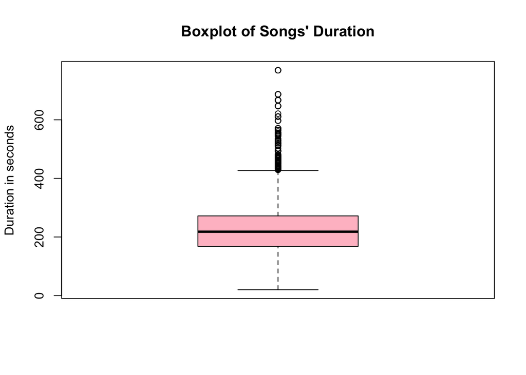

```r
songs_selected$duration_min %>% period_to_seconds() %>% boxplot(main="Boxplot of Songs' Duration", ylab="Duration in seconds", col = "pink")
```

+ Menurut metode Tukey, variabel durasi nampaknya memiliki banyak outlier.

- Untuk mengetahui berapa banyak outlier yang ada, kita akan melihat z-score menggunakan fungsi score() dari paket outliers. Pertama, kita harus memastikan apakah distribusi kita mendekati normal. Untuk ini, kita menerapkan fungsi hist() untuk melihat histogram.

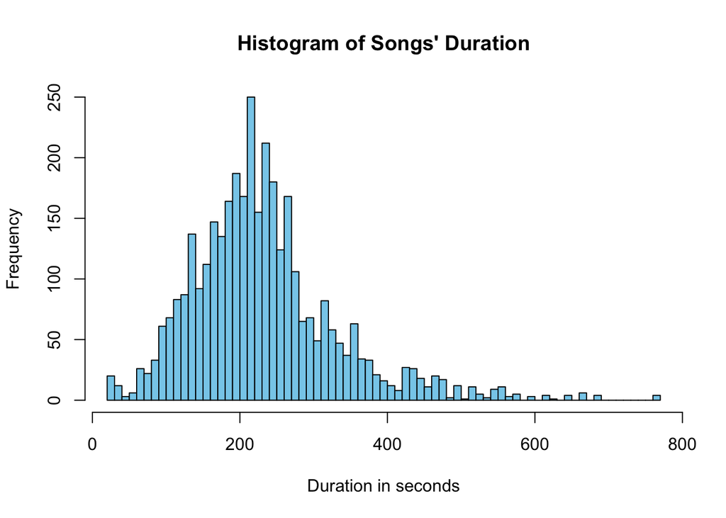

```r
songs_selected$duration_min %>% period_to_seconds() %>% hist(main="Histogram of Songs' Duration", xlab="Duration in seconds", breaks=100, col="skyblue")
```

```r
z.scores <- songs_selected$duration_min %>% period_to_seconds() %>% scores(type = "z")
z.scores %>% summary()
```

```
##    Min. 1st Qu.  Median    Mean 3rd Qu.    Max.
## -2.1315 -0.6481 -0.1469  0.0000  0.3944  5.3759
```

- Dengan menggunakan fungsi summary(), kami menemukan bahwa nilai rata-rata mendekati nol, yang menunjukkan bahwa kumpulan data memiliki distribusi yang relatif seimbang di sekitar nilai rata-rata. Namun, keberadaan nilai maksimum yang sangat besar (5.3759) menunjukkan keberadaan outlier potensial yang secara signifikan memengaruhi rentang data secara keseluruhan.
- Terakhir, kami menerapkan fungsi which() untuk melihat lokasi nilai z-score absolut yang lebih besar dari tiga dan menghitung jumlahnya menggunakan fungsi length(). Z-score yang lebih besar dari tiga (dalam nilai absolut) sering dianggap sebagai indikator outlier.

```r
which(abs(z.scores) >3 )
```

```
##  [1]   33   34   35   36  168  416  417  747  748  749  750  751  752  811 1053
## [16] 1254 1316 1317 1318 1319 1320 1321 1322 1323 1324 1325 1326 1327 1492 1493
## [31] 1498 1499 1500 1501 1788 2412 2413 2414 2415 2416 2417 2424 2425 2426 2935
## [46] 2936 2937 2938 2939 2940 2982 2983 2984 2985 3214 3530
```